# Investigate a TMDb movie Database

- Introduction
  - Questions to be Answered
  - Wrangling & Cleaning
- Data Cleaning
- Data Wrangling
- Exploratory Data Analysis
  - Question 1
  - Question 2
- Conclusion

## Introduction

In this project I will investigate a TMDb movies database file which has collection of important detials of movies, including their details of budget, revenue and release dates.

```python
import pandas as pd
import os
path = os.getcwd()
print(path)

# load the data from CSV file
data = pd.read_csv('tmdb-movies.csv')

#first 5 rows (excluding headers) of tmdb database
data.head()
```

```
C:\Users\Virendra\investigate a dataset
```

|  | id | imdb_id | popularity | budget | revenue | original_title | cast | homepage | director | tagline | ... | overview | runtime | genres | production_companies | release_date | vote_count | vote_average | release_year | budget_adj | revenue_adj |
| --- | --- | --- | --- | --- | --- | --- | --- | --- | --- | --- | --- | --- | --- | --- | --- | --- | --- | --- | --- | --- | --- |
| 0 | 135397 | tt0369610 | 32.985763 | 150000000 | 1513528810 | Jurassic World | Chris Pratt\|Bryce Dallas Howard\|Irrfan Khan\|Vi... | http://www.jurassicworld.com/ | Colin Trevorrow | The park is open. | ... | Twenty-two years after the events of Jurassic ... | 124 | Action\|Adventure\|Science Fiction\|Thriller | Universal Studios\|Amblin Entertainment\|Legenda... | 6/9/15 | 5562 | 6.5 | 2015 | 1.379999e+08 | 1.392446e+09 |
| 1 | 76341 | tt1392190 | 28.419936 | 150000000 | 378436354 | Mad Max: Fury Road | Tom Hardy\|Charlize Theron\|Hugh Keays-Byrne\|Nic... | http://www.madmaxmovie.com/ | George Miller | What a Lovely Day. | ... | An apocalyptic story set in the furthest reach... | 120 | Action\|Adventure\|Science Fiction\|Thriller | Village Roadshow Pictures\|Kennedy Miller Produ... | 5/13/15 | 6185 | 7.1 | 2015 | 1.379999e+08 | 3.481613e+08 |
| 2 | 262500 | tt2908446 | 13.112507 | 110000000 | 295238201 | Insurgent | Shailene Woodley\|Theo James\|Kate Winslet\|Ansel... | http://www.thedivergentseries.movie/#insurgent | Robert Schwentke | One Choice Can Destroy You | ... | Beatrice Prior must confront her inner demons ... | 119 | Adventure\|Science Fiction\|Thriller | Summit Entertainment\|Mandeville Films\|Red Wago... | 3/18/15 | 2480 | 6.3 | 2015 | 1.012000e+08 | 2.716190e+08 |
| 3 | 140607 | tt2488496 | 11.173104 | 200000000 | 2068178225 | Star Wars: The Force Awakens | Harrison Ford\|Mark Hamill\|Carrie Fisher\|Adam D... | http://www.starwars.com/films/star-wars-episod... | J.J. Abrams | Every generation has a story. | ... | Thirty years after defeating the Galactic Empi... | 136 | Action\|Adventure\|Science Fiction\|Fantasy | Lucasfilm\|Truenorth Productions\|Bad Robot | 12/15/15 | 5292 | 7.5 | 2015 | 1.839999e+08 | 1.902723e+09 |
| 4 | 168259 | tt2820852 | 9.335014 | 190000000 | 1506249360 | Furious 7 | Vin Diesel\|Paul Walker\|Jason Statham\|Michelle ... | http://www.furious7.com/ | James Wan | Vengeance Hits Home | ... | Deckard Shaw seeks revenge against Dominic Tor... | 137 | Action\|Crime\|Thriller | Universal Pictures\|Original Film\|Media Rights ... | 4/1/15 | 2947 | 7.3 | 2015 | 1.747999e+08 | 1.385749e+09 |

5 rows × 21 columns

### About the dataset provided?

- We will assume columns like *'budget', 'revenue', 'budget_adj', 'revenue_adj'* represent currency in dollars.

### Questions can be brainstormed?

- Which movie gained the most profit or which movie has been the people's favourite?
- Which year the movies made the most profit?
- What are the similar characteristics of movies which have gained highest profits?

### What needs to be Wrangled and Cleaned

- In this section of the report, I will check the data, and then identify areas to improve and clean the dataset for analysis..

### Questions to be Answered

1. General questions about the dataset.
1. Which movie earns the most and least profit?
2. Which movie had the greatest and least budget?
3. What is the average runtime of all movies?
2. What are the similar characteristics does the most profitable movie have?
1. Average duration of movies.
2. Average Budget.
3. Average profits.

## Data Cleaning

I perform the cleaning steps in this section.. First, I will drop extraneous columns that are not relevant to my questions.

```python
# import all the libraries
import numpy as np
from matplotlib import pyplot as plt
import seaborn as sns

#store the database of tmdb movies into a dataframe
movieData = pd.read_csv('tmdb-movies.csv')
```

Check how many entries we have in this dataset and features.

```python
rows, col = movieData.shape
# we need to remove header from its count.
print('Total entries {}  of movies and {} columns of it.'.format(rows-1, col))
```

```
Total entries 10865  of movies and 21 columns of it.
```

```python
#list of movies needs to be deleted
del_col = [ 'id', 'imdb_id', 'popularity', 'budget_adj', 'revenue_adj', 'homepage', 'keywords', 'overview', 'production_companies', 'vote_count', 'vote_average']

#deleting the extraneous columns
movieData = movieData.drop(del_col, 1)
movieData.head(3)
```

|  | budget | revenue | original_title | cast | director | tagline | runtime | genres | release_date | release_year |
| --- | --- | --- | --- | --- | --- | --- | --- | --- | --- | --- |
| 0 | 150000000 | 1513528810 | Jurassic World | Chris Pratt\|Bryce Dallas Howard\|Irrfan Khan\|Vi... | Colin Trevorrow | The park is open. | 124 | Action\|Adventure\|Science Fiction\|Thriller | 6/9/15 | 2015 |
| 1 | 150000000 | 378436354 | Mad Max: Fury Road | Tom Hardy\|Charlize Theron\|Hugh Keays-Byrne\|Nic... | George Miller | What a Lovely Day. | 120 | Action\|Adventure\|Science Fiction\|Thriller | 5/13/15 | 2015 |
| 2 | 110000000 | 295238201 | Insurgent | Shailene Woodley\|Theo James\|Kate Winslet\|Ansel... | Robert Schwentke | One Choice Can Destroy You | 119 | Adventure\|Science Fiction\|Thriller | 3/18/15 | 2015 |

This database only contains columns that are needed for analysis.

Now clean if any duplicate rows.

```python
#drop duplicate rows
movieData.drop_duplicates(keep = 'first', inplace = True)

rows, col = movieData.shape
print('Total entries {}  of movies and {} columns after cleaning.'.format(rows-1, col))
```

```
Total entries 10864  of movies and 10 columns after cleaning.
```

Now we have 10864 movie entries.

**deleting those movies from the database, which have a value of `'0'` in their `budget` or `revenue`.**

```python
#list of column that needs to be verified
check_row = ['budget', 'revenue']

#replace the value of '0' to NaN
movieData[check_row] = movieData[check_row].replace(0, np.NaN)

#drop any row which has NaN
movieData.dropna(subset = check_row, inplace = True)

rows, col = movieData.shape
print('Now, we have only {} entries.'.format(rows-1))
```

```
Now, we have only 3853 entries.
```

## Data Wrangling

**Check if we have any movie with a runtime value of `0`. If we have any, we will replace with `NaN`.**

```python
#replacing 0 with NaN
movieData['runtime'] = movieData['runtime'].replace(0, np.NaN)
```

**convert the `'release_date'` column to date format**

```python
#format data
movieData.release_date = pd.to_datetime(movieData['release_date'])

movieData.head(2)
```

|  | budget | revenue | original_title | cast | director | tagline | runtime | genres | release_date | release_year |
| --- | --- | --- | --- | --- | --- | --- | --- | --- | --- | --- |
| 0 | 150000000.0 | 1.513529e+09 | Jurassic World | Chris Pratt\|Bryce Dallas Howard\|Irrfan Khan\|Vi... | Colin Trevorrow | The park is open. | 124 | Action\|Adventure\|Science Fiction\|Thriller | 2015-06-09 | 2015 |
| 1 | 150000000.0 | 3.784364e+08 | Mad Max: Fury Road | Tom Hardy\|Charlize Theron\|Hugh Keays-Byrne\|Nic... | George Miller | What a Lovely Day. | 120 | Action\|Adventure\|Science Fiction\|Thriller | 2015-05-13 | 2015 |

date format changed for `'release_date'` column to (year-month-day)

**Now all columns are in the format that we want for our calculations.**

```python
#datatypes of all the columns
movieData.dtypes
```

```
budget                   float64
revenue                  float64
original_title            object
cast                      object
director                  object
tagline                   object
runtime                    int64
genres                    object
release_date      datetime64[ns]
release_year               int64
dtype: object
```

We have float values for `'budget'` and `'revenue'` columns, we will convert them from float to int.

```python
#changes the columns data type
change_coltype = ['budget', 'revenue']

movieData[change_coltype] = movieData[change_coltype].applymap(np.int64)

movieData.dtypes
```

```
budget                     int64
revenue                    int64
original_title            object
cast                      object
director                  object
tagline                   object
runtime                    int64
genres                    object
release_date      datetime64[ns]
release_year               int64
dtype: object
```

```python
#renames the columns
movieData.rename(columns = {'budget' : 'budget_(in_US-Dollars)', 'revenue' : 'revenue_(in_US-Dollars)'}, inplace = True)
```

## Data Analysis

**Find the profits of each movie.**

```python
movieData.insert(2, 'profit_(in_US_Dollars)', movieData['revenue_(in_US-Dollars)'] - movieData['budget_(in_US-Dollars)'])

#we change the data type to int
movieData['profit_(in_US_Dollars)'] = movieData['profit_(in_US_Dollars)'].apply(np.int64)

movieData.head(2)
```

|  | budget_(in_US-Dollars) | revenue_(in_US-Dollars) | profit_(in_US_Dollars) | original_title | cast | director | tagline | runtime | genres | release_date | release_year |
| --- | --- | --- | --- | --- | --- | --- | --- | --- | --- | --- | --- |
| 0 | 150000000 | 1513528810 | 1363528810 | Jurassic World | Chris Pratt\|Bryce Dallas Howard\|Irrfan Khan\|Vi... | Colin Trevorrow | The park is open. | 124 | Action\|Adventure\|Science Fiction\|Thriller | 2015-06-09 | 2015 |
| 1 | 150000000 | 378436354 | 228436354 | Mad Max: Fury Road | Tom Hardy\|Charlize Theron\|Hugh Keays-Byrne\|Nic... | George Miller | What a Lovely Day. | 120 | Action\|Adventure\|Science Fiction\|Thriller | 2015-05-13 | 2015 |

### Q1

### 1A

#### Which movie earns the most and least profit?

```python
#function to calculates lowest and highest values of columns
def highest_lowest(column_name):

    #highest
    highest_id = movieData[column_name].idxmax()

    highest_details = pd.DataFrame(movieData.loc[highest_id])

    #lowest
    lowest_id = movieData[column_name].idxmin()
    lowest_details = pd.DataFrame(movieData.loc[lowest_id])

    #concatenating two dataframes
    two_in_one_data = pd.concat([highest_details, lowest_details], axis = 1)

    return two_in_one_data

highest_lowest('profit_(in_US_Dollars)')
```

|  | 1386 | 2244 |
| --- | --- | --- |
| budget_(in_US-Dollars) | 237000000 | 425000000 |
| revenue_(in_US-Dollars) | 2781505847 | 11087569 |
| profit_(in_US_Dollars) | 2544505847 | -413912431 |
| original_title | Avatar | The Warrior's Way |
| cast | Sam Worthington\|Zoe Saldana\|Sigourney Weaver\|S... | Kate Bosworth\|Jang Dong-gun\|Geoffrey Rush\|Dann... |
| director | James Cameron | Sngmoo Lee |
| tagline | Enter the World of Pandora. | Assassin. Hero. Legend. |
| runtime | 162 | 100 |
| genres | Action\|Adventure\|Fantasy\|Science Fiction | Adventure\|Fantasy\|Action\|Western\|Thriller |
| release_date | 2009-12-10 00:00:00 | 2010-12-02 00:00:00 |
| release_year | 2009 | 2010 |

The first column shows the highest profit made by a movie and second column shows the highest in loss movie in this dataset.

### 1B

#### Which movie had the greatest and least budget?

```python
highest_lowest('budget_(in_US-Dollars)')
```

|  | 2244 | 2618 |
| --- | --- | --- |
| budget_(in_US-Dollars) | 425000000 | 1 |
| revenue_(in_US-Dollars) | 11087569 | 100 |
| profit_(in_US_Dollars) | -413912431 | 99 |
| original_title | The Warrior's Way | Lost & Found |
| cast | Kate Bosworth\|Jang Dong-gun\|Geoffrey Rush\|Dann... | David Spade\|Sophie Marceau\|Ever Carradine\|Step... |
| director | Sngmoo Lee | Jeff Pollack |
| tagline | Assassin. Hero. Legend. | A comedy about a guy who would do anything to ... |
| runtime | 100 | 95 |
| genres | Adventure\|Fantasy\|Action\|Western\|Thriller | Comedy\|Romance |
| release_date | 2010-12-02 00:00:00 | 1999-04-23 00:00:00 |
| release_year | 2010 | 1999 |

we can see that `The Warriors Way` had the highest budget of all movies in the dataset of about `$425M`. This same movie also had the highest loss.

### 1C

#### What is the average runtime of all movies?

```python
#average of a given column
def average_func(column_name):

    return movieData[column_name].mean()
```

```python
average_func('runtime')
```

```
109.22029060716139
```

**The average runtime of all movies in this dataset is `109 mins` approx.**

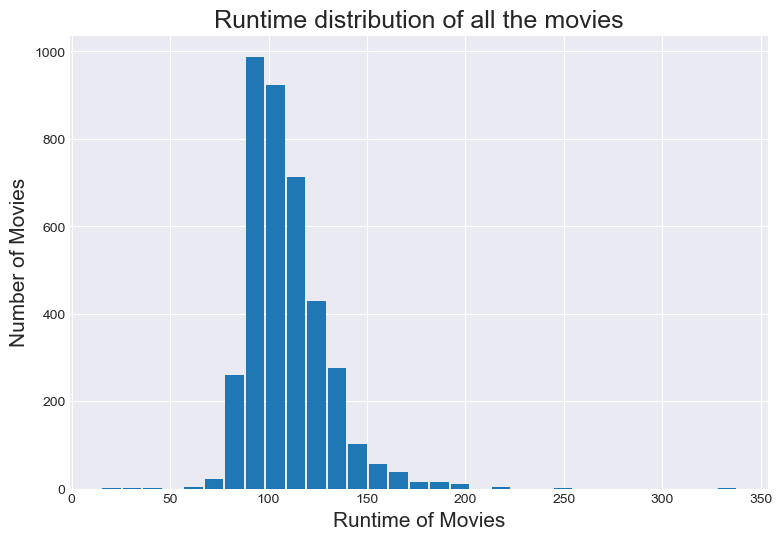

```python
#plotting a histogram

sns.set_style('darkgrid')

plt.rc('xtick', labelsize = 10)
plt.rc('ytick', labelsize = 10)

plt.figure(figsize=(9,6), dpi = 100)
plt.xlabel('Runtime of Movies', fontsize = 15)
plt.ylabel('Number of Movies', fontsize=15)
plt.title('Runtime distribution of all the movies', fontsize=18)

plt.hist(movieData['runtime'], rwidth = 0.9, bins =31)

plt.show()
```

The above graph shows us that how many movies lie between the time interval x1 to x2.

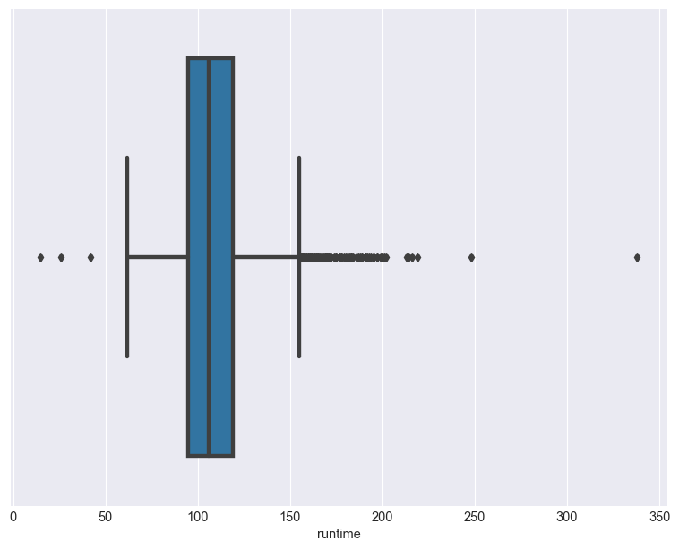

```python
#giving two plots, thr first is the box plot, second is plots of runtime for movies
# figure size
plt.figure(figsize=(9,7), dpi = 105)

#using seaborn to plot
#plotting box plot
sns.boxplot(movieData['runtime'], linewidth = 3)
#showing the plot
plt.show()
```

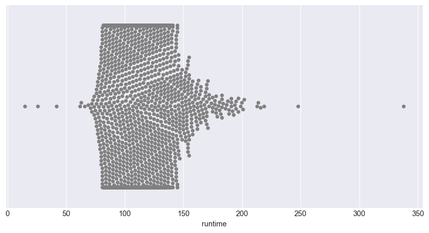

```python
#data points of runtime of movies

plt.figure(figsize=(10,5), dpi = 105)
sns.swarmplot(movieData['runtime'], color = 'grey')
plt.show()
```

```python
#runtime points at x positions
movieData['runtime'].describe()
```

```
count    3854.000000
mean      109.220291
std        19.922820
min        15.000000
25%        95.000000
50%       106.000000
75%       119.000000
max       338.000000
Name: runtime, dtype: float64
```

We are now done with exploring the dataset given. Now we want to find similar characteristics of most profitable movies.

### Q2

### 2A

#### Average Duration of movies

**Let's take only the movies who made profits of 50M dollars or more.**

```python
profitMovieData = movieData[movieData['profit_(in_US_Dollars)'] >= 50000000]

profitMovieData.index = range(len(profitMovieData))

profitMovieData.index = profitMovieData.index + 1

profitMovieData.head(2)
```

|  | budget_(in_US-Dollars) | revenue_(in_US-Dollars) | profit_(in_US_Dollars) | original_title | cast | director | tagline | runtime | genres | release_date | release_year |
| --- | --- | --- | --- | --- | --- | --- | --- | --- | --- | --- | --- |
| 1 | 150000000 | 1513528810 | 1363528810 | Jurassic World | Chris Pratt\|Bryce Dallas Howard\|Irrfan Khan\|Vi... | Colin Trevorrow | The park is open. | 124 | Action\|Adventure\|Science Fiction\|Thriller | 2015-06-09 | 2015 |
| 2 | 150000000 | 378436354 | 228436354 | Mad Max: Fury Road | Tom Hardy\|Charlize Theron\|Hugh Keays-Byrne\|Nic... | George Miller | What a Lovely Day. | 120 | Action\|Adventure\|Science Fiction\|Thriller | 2015-05-13 | 2015 |

```python
#number of rows in a dataframe
len(profitMovieData)
```

```
1338
```

Now we have only 1338 rows, meaning more than 2500+ movies made profits less than \$50M.

```python
def prof_avg_fuc(column_name):
    return profitMovieData[column_name].mean()
```

```python
prof_avg_fuc('runtime')
```

```
113.66741405082212
```

The mean time for movies making significant profits is likely similar to the mean runtime of movies that we found before of `109.2` which included movies having less than $50M profits. Difference of 4 minutes.

### 2B

#### Average Budget of Movies

```python
prof_avg_fuc('budget_(in_US-Dollars)')
```

```
60444957.76083707
```

The average budget of movies of $50M club in profit is around `$60M dollars`.

### 2C

#### Average Profit of Movies

```python
prof_avg_fuc('profit_(in_US_Dollars)')
```

```
194512704.83408073
```

The average profits of movies of $50M club in profit is around `$194M dollars`.

### 2D

#### Which genre were more successful?

```python
def extract_data(column_name):
    all_data = profitMovieData[column_name].str.cat(sep = '|')

    all_data = pd.Series(all_data.split('|'))

    count = all_data.value_counts(ascending = False)

    return count
```

```python
genre_count = extract_data('genres')
#shwoing top 5 values
genre_count.head()
```

```
Comedy       492
Drama        481
Action       464
Thriller     405
Adventure    379
dtype: int64
```

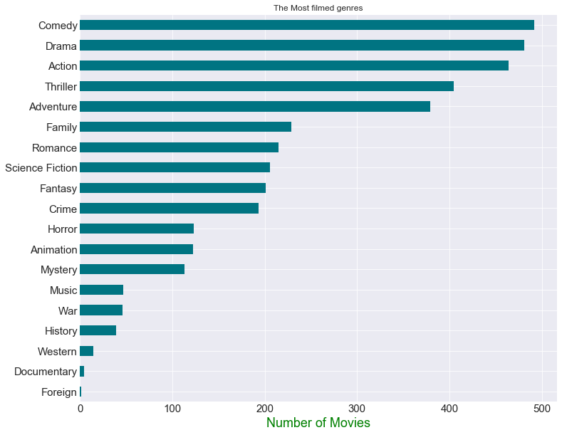

```python
#plot points in descending order top to bottom
genre_count.sort_values(ascending = True, inplace = True)

ax = genre_count.plot.barh(color = '#007482', fontsize = 15)

ax.set(title = 'The Most filmed genres')

#x-label
ax.set_xlabel('Number of Movies', color = 'g', fontsize = '18')

#giving the figure size(width, height)
ax.figure.set_size_inches(12, 10)

#shwoing the plot
plt.show()
```

`Action, Drama and Comedy genres` are the most as visualized but Comedy takes the prize, about `492 movies` have genres comedy which make $50M+ in profit.

find one more key characteristic of these movies.

### 2E

#### Which month released highest number of movies in all of the years? And which month made the most profit?

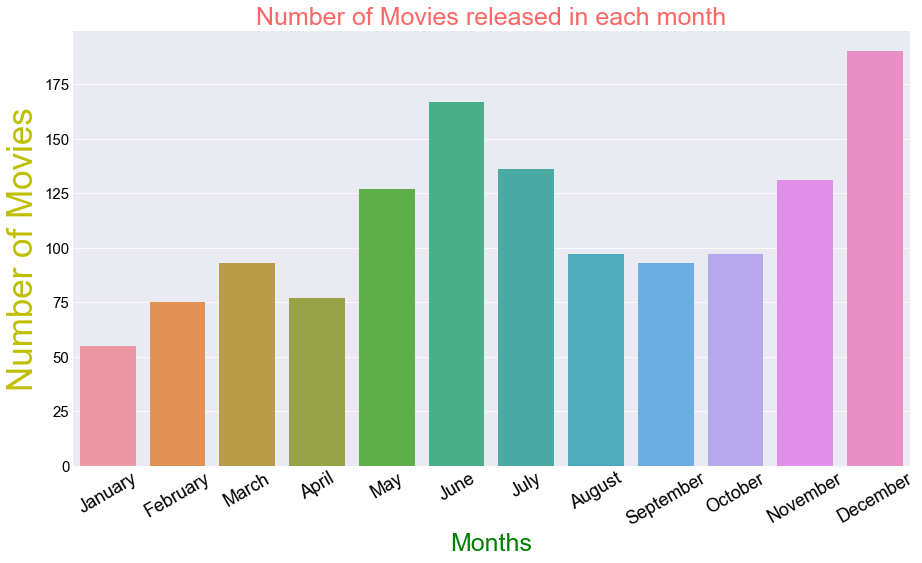

```python
#group all of the months of years and then calculate the profits of those months

index_release_date = profitMovieData.set_index('release_date')

#group all the data by month
groupby_index = index_release_date.groupby([(index_release_date.index.month)])

monthly_movie_count = groupby_index['profit_(in_US_Dollars)'].count()

monthly_movie_count= pd.DataFrame(monthly_movie_count)

month_list = ['January', 'February', 'March', 'April', 'May', 'June', 'July', 'August', 'September', 'October', 'November', 'December']

monthly_movie_count_bar = sns.barplot(x = monthly_movie_count.index, y = monthly_movie_count['profit_(in_US_Dollars)'], data = monthly_movie_count)

monthly_movie_count_bar.figure.set_size_inches(15,8)

monthly_movie_count_bar.axes.set_title('Number of Movies released in each month', color="r", fontsize = 25, alpha = 0.6)

#x-label
monthly_movie_count_bar.set_xlabel("Months", color="g", fontsize = 25)
#y-label
monthly_movie_count_bar.set_ylabel("Number of Movies", color="y", fontsize = 35)

monthly_movie_count_bar.tick_params(labelsize = 15, labelcolor="black")

monthly_movie_count_bar.set_xticklabels(month_list, rotation = 30, size = 18)

plt.show()
```

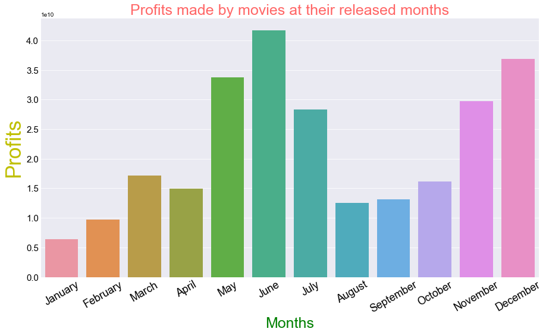

```python
#second part

monthly_profit = groupby_index['profit_(in_US_Dollars)'].sum()

monthly_profit = pd.DataFrame(monthly_profit)

monthly_profit_bar = sns.barplot(x = monthly_profit.index, y = monthly_profit['profit_(in_US_Dollars)'], data = monthly_profit)

monthly_profit_bar.figure.set_size_inches(15,8)

monthly_profit_bar.axes.set_title('Profits made by movies at their released months', color="r", fontsize = 25, alpha = 0.6)

#x-label
monthly_profit_bar.set_xlabel("Months", color="g", fontsize = 25)
#y-label
monthly_profit_bar.set_ylabel("Profits", color="y", fontsize = 35)

monthly_profit_bar.tick_params(labelsize = 15, labelcolor="black")

monthly_profit_bar.set_xticklabels(month_list, rotation = 30, size = 18)

plt.show()
```

## Conclusion

There are a lot of unreported runtime, budget and revenue for this dataset, resulting in only about 35% of the observations in the dataset being used for the analysis.

Genres' column contains multiple values separated by pipe characters. Hence, the assumption for this analysis is that a movie may have more than one genre. If only movie only has one genre, the result could be different.